# Project3

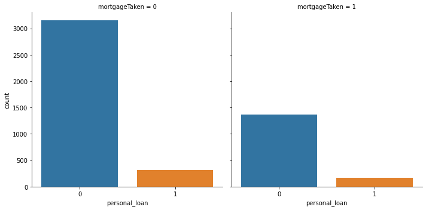

```python
sns.catplot(x="personal_loan", kind="count", col="mortgageTaken", data=loan)
```

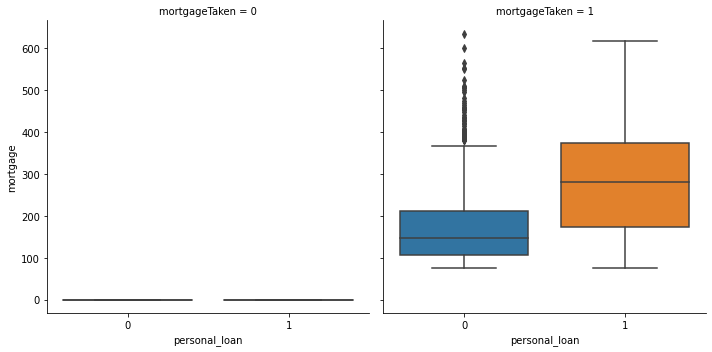

```python
sns.catplot(y="mortgage", x="personal_loan", kind="box", col="mortgageTaken", data=loan)
```

- For the customers who have mortgage, they have higher chance of taking a loan out
  - The amount of mortgage they is also higher for customers who took out loan in comparison to the customers who didn't take out loan
- #### Loan acceptance with CD account

```
personal_loan     0    1   All
cd_account
All            4520  480  5000
0              4358  340  4698
1               162  140   302
------------------------------------------------------------------------------------------------------------------------
```

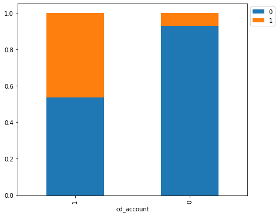

```python
stacked_barplot(loan, "cd_account", "personal_loan")
```

- There is a much higher chance of someone having a CD account to take out a loan.
- #### Loan acceptance with education level

```
personal_loan     0    1   All
education
All            4520  480  5000
3              1296  205  1501
2              1221  182  1403
1              2003   93  2096
------------------------------------------------------------------------------------------------------------------------
```

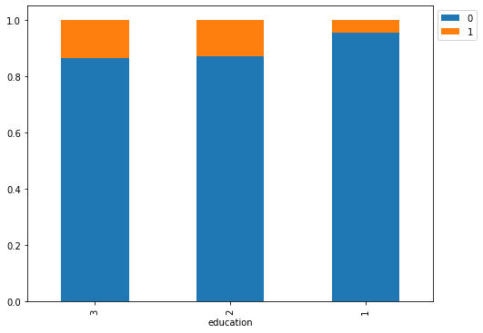

```python
stacked_barplot(loan, "education", "personal_loan")
```

- The tendency of a customer for taking out a loan is higher with higher education (graduate or advanced/professional)
- #### Loan acceptance with family size

```
personal_loan     0    1   All
family
All            4520  480  5000
4              1088  134  1222
3               877  133  1010
1              1365  107  1472
2              1190  106  1296
------------------------------------------------------------------------------------------------------------------------
```

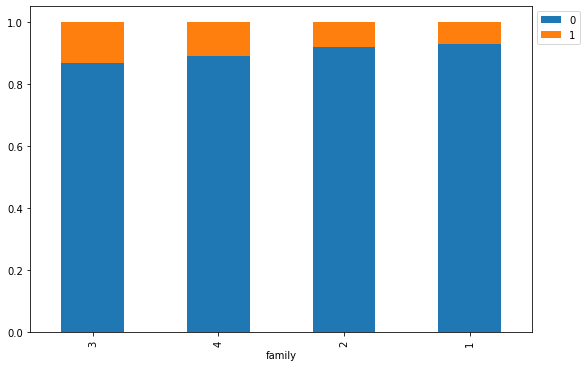

```python
stacked_barplot(loan, "family", "personal_loan")
```

- Bigger families (3 or 4) members have higher chances of taking out a loan
- #### Multivariate analysis of numerical variables

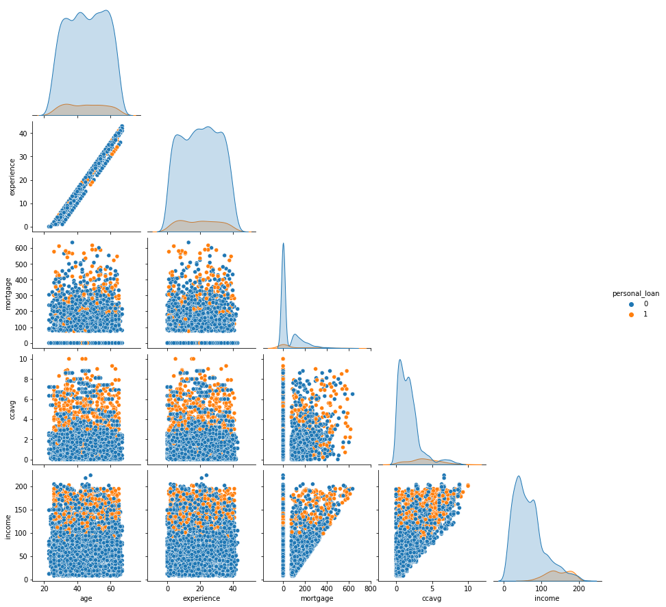

```python
sns.pairplot(
    loan[["age", "experience", "mortgage", "ccavg", "income", "personal_loan"]],
    hue="personal_loan",
    corner=True,
)
```

```python
corr = loan[["age", "experience", "mortgage", "ccavg", "income"]].corr()
```

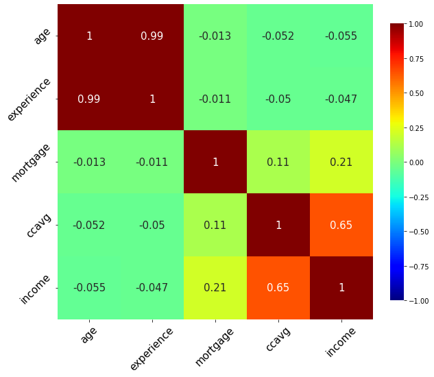

```python
# Show the coorelation of numerical values on a color coded matrix
fig, ax = plt.subplots(nrows=1, ncols=1, figsize=(8, 8))
fig.tight_layout(pad=2.0)

sns.heatmap(
    corr,
    annot=True,
    ax=ax,
    annot_kws={"fontsize": 15},
    cmap="jet",
    vmin=-1,
    vmax=1,
    square=True,
    cbar_kws={"fraction": 0.04},
)
ax.tick_params(axis="both", rotation=45, labelsize=15)
```